# Visualização de Dados (parte 02)

Análise de Dados Financeiros e Econômicos com o R

Marcelo S. Perlin

EA-UFRGS

01/10/2026

# Mapas com o R

## Introdução

> a representação de dados em mapas é uma das técnicas de visualização de dados mais utilizadas pela mídia jornalística;
- a abordagem de camadas é intuitiva (uma camada para a representação visual da área geográfica, e outra para os pontos e preenchimentos)
- R oferece um ecossistema de pacotes baseados no `ggplot2` que facilitam a construção de mapas

## Exemplo de mapa

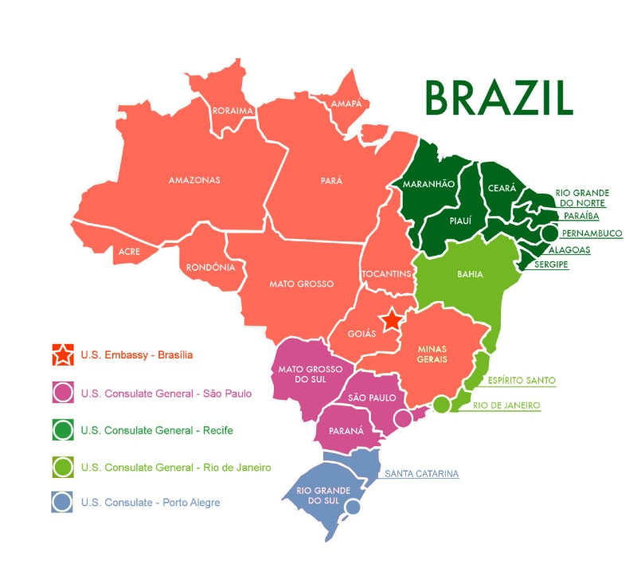

Localização de consulados e embaixadas americanas no Brasil

## Pacote **geobr** (Pereira and Goncalves 2023)

- arquivos de dados geográficos contendo o território nacional são disponibilizados no site do [IBGE](https://www.ibge.gov.br/).
- O pacote `geobr` (Pereira and Goncalves 2023) [(IPEA)](https://www.ipea.gov.br/portal/) é uma API para acesso aos dados do IBGE.

## O formato SF (*simple features*)

- O formato *SF* foi criado pela [*Open Geospatial Consortium*](https://www.ogc.org/) e é eficiente para a representação de mapas geográficos.
- No R, um mapa SF é um `tibble` com uma coluna especial de **geometria**, que guarda os polígonos (áreas) ou pontos junto com os metadados.
- O `ggplot2` desenha esses objetos com a camada `geom_sf()`.

## Exemplo `geobr` (1)

```r
library(dplyr)

data_year <- 2019
br <- geobr::read_country(
  year = data_year,
  showProgress = FALSE
)

dplyr::glimpse(br)
```

```
Rows: 1
Columns: 2
$ year     <dbl> 2019
$ geometry <MULTIPOLYGON [°]> MULTIPOLYGON (((-49.70495 -...
```

## Exemplo `geobr` (2)

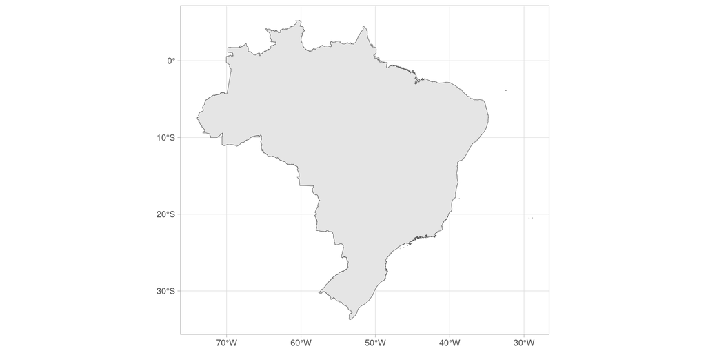

Mapa do Brasil

```r
library(ggplot2)

p0 <- ggplot(data = br) +
  geom_sf() +
  theme_light()

p0
```

## Exemplo `geobr` – cidades e capitais

```r
df_cities <- vdr::data_import(
  "Chapter07-latlong-cities-brazil.csv"
)

p1 <- p0 +
  geom_point(data = df_cities,
             mapping = aes(y = latitude, x = longitude),
             size = 0.05,
             color = "blue",
             alpha = 0.35) +
  geom_point(data = df_cities |> filter(capital == TRUE),
             mapping = aes(y = latitude, x = longitude),
             size = 1.5,
             color = 'red') +
  labs(title = "Cidades do Brasil",
       subtitle = "Capitais dos estados em vermelho",
       caption = "Dados do IBGE (2019)")

p1
```

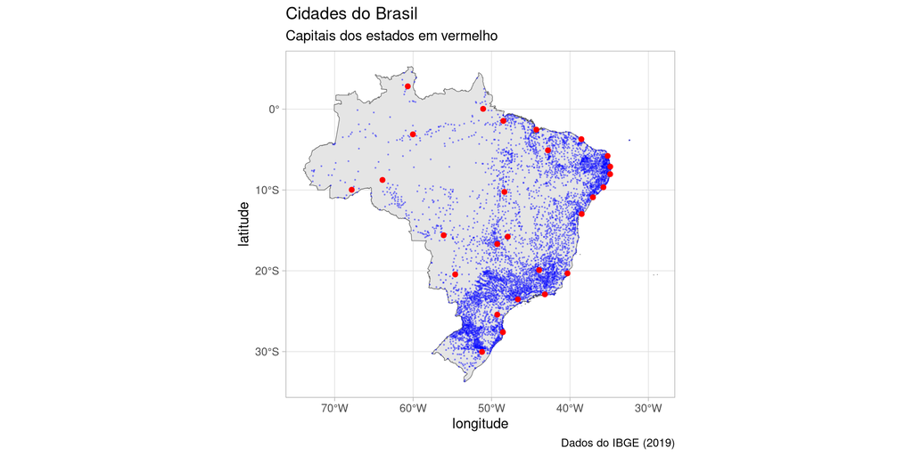

Mapa de cidades e capitais do Brasil

## Exemplo `geobr` – Rendimento mensal domiciliar

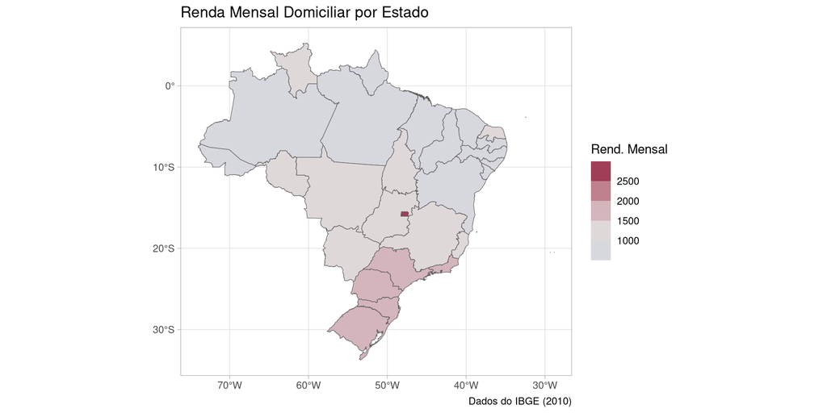

```r
df_ibge <- vdr::data_import(
  "Chapter07-data-ibge.csv"
)

data_year <- 2010
states <- geobr::read_state(code_state = "all",
                            year = data_year,
                            showProgress = FALSE) |>
  left_join(df_ibge, by = c("code_state" = "codigo"))

p <- ggplot(data = states,
            aes(fill = rendimento_mensal_domiciliar)) +
  geom_sf() +
  theme_light() +
  labs(fill = "Rend. Mensal",
       title = "Renda Mensal Domiciliar por Estado",
       caption = "Dados do IBGE (2010)") +
  colorspace::scale_fill_binned_diverging(
    "Blue-Red",
    mid = median(states$rendimento_mensal_domiciliar))

p
```

## Pacote **ggmap** (Kahle et al. 2023)

- API online para a importação de mapas do [Google Maps](https://www.google.com.br/maps?hl=pt-BR&tab=wl) e [Stamen Maps](http://maps.stamen.com/).
- Disponibiliza mapas atualizados do mundo inteiro!
- **Google maps exige registro de projeto e cartão de crédito!**

## Registrando um projeto no Google

1. Registre-se no Google através de um email. Caso já tenha uma conta, pule esse passo e faça o login no *browser* de preferência.
2. Acesse o site https://console.cloud.google.com/ e clique em “New Project”, definindo o nome do projeto e a localização.
3. Ative o serviço de “Google Maps” para o projeto criado anteriormente.
4. Recolha a chave na seção “Credentials”

## Usando o API

```r
library(ggmap)

google_key <- "YOUR_KEY_HERE"

register_google(
  key = google_key,
  account_type = 'standard'
)
```

Após o registro da chave, teste a chamada ao API com um comando simples:

```r
ggmap::geocode("Porto Alegre RS")
```

```
# A tibble: 1 × 2
    lon   lat
  <dbl> <dbl>
1 -51.2 -30.0
```

## Utilizando `ggmap`

```r
sc <- ggmap::get_map(
  "state of santa catarina, brazil",
  maptype = "terrain",
  zoom = 7)

p_sc <- ggmap::ggmap(sc) +
  labs(
    title = "Estado de Santa Catarina",
    caption = "Dados do Google Maps"
  )

p_sc
```

[figure not shown]

Exemplo de mapa para o estado de Santa Catarina

## Codificação geográfica

- codificação geográfica é a busca de latitude e longitude a partir de um texto (*string*)

```r
ea_ufrgs <- ggmap::geocode("Escola de Administração UFRGS")

ea_ufrgs
```

```
# A tibble: 1 × 2
    lon   lat
  <dbl> <dbl>
1 -51.2 -30.0
```

Com a latitude e longitude do local em mãos, fica fácil de mostrar no mapa o ponto de interesse:

```r
poa <- ggmap::get_map("Escola de Administração UFRGS",
                      zoom = 15)

p_ea <- ggmap::ggmap(poa) +
  labs(
    title = "Cidade de Porto Alegre",
    subtitle = "Localização Escola de Adm., UFRGS",
    caption = "Dados do Google Maps") +
  geom_point(data = ea_ufrgs,
             aes(x = lon,
                 y = lat),
             size = 5,
             color = "red") +
  geom_text(data = ea_ufrgs,
            aes(x = lon,
                y = lat,
                label = "EA-UFRGS"),
            nudge_y = 0.00075,
            color = "blue")

p_ea
```

[figure not shown]

# Programando com o `ggplot2`

## Programação com o `ggplot2`

> A plataforma R fornece um ambiente computacional completo para automatizar qualquer tarefa de visualização de dados.

Aqui aprenderemos:

- Criação e exportação de figuras via funções;
- Teste de temas para figuras;

## Criando figuras via funções

- A saída de **ggplot2::ggplot()** é um objeto do R como qualquer outro
- Podemos manipular esse objeto facilmente!
- Imagine o seguinte problema:
  - precisa criar um gráfico do preço do índice SP500 para anos diferentes, onde cada ano terá um gráfico individual, salvo em arquivo separado.

## Solução

1. criar função com parâmetros de interesse
2. aplicar função a anos diferentes

```r
plot_year <- function(this_year, df_yf) {

  df_year <- df_yf |>
    filter(
      lubridate::year(ref_date) == this_year
    )

  p <- ggplot(df_year,
              aes(x = ref_date,
                  y = price_adjusted)) +
    geom_line() +
    labs(x = "Ano",
         y = "SP500",
         title = paste0("SP500 no ano de ", this_year),
         caption = "Dados do Yahoo Finance"
    ) +
    theme_light()

  return(p)
}
```

Para testar a função, vamos importar os dados do SP500 e criar o gráfico para o ano de 2020:

```r
df_yf <- vdr::data_import(
  "Chapter04-sp500-1950-2022.csv"
)

p <- plot_year(2020, df_yf)

p
```

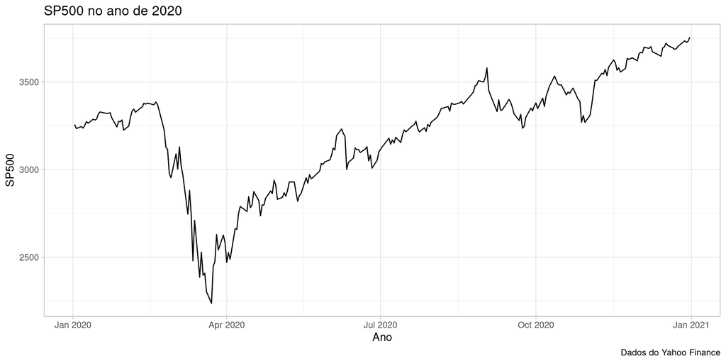

SP500 para o ano 2020

Aplicando a um vetor de anos:

```r
years_to_plot <- 2000:2020

l_p <- purrr::map(
  .x = years_to_plot,
  .f = plot_year,
  df_yf = df_yf
)
```

O primeiro elemento de `l_p` é o gráfico para o ano de 2000:

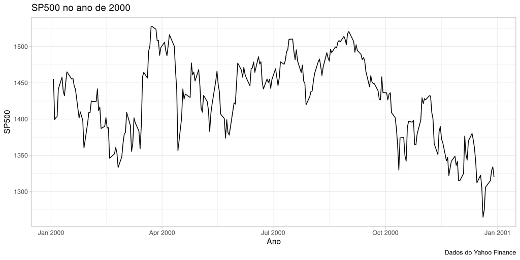

SP500 para o ano 2000

```r
l_p[[1]]
```

## Iterando com `purrr` (vs. `for`)

- `purrr::map()` aplica uma função a cada elemento de um vetor e devolve uma **lista** com os resultados.
- É equivalente a um laço `for`, porém mais conciso e sem a necessidade de “pré-alocar” a lista:

```r
# equivalente usando for
l_p <- vector("list", length(years_to_plot))

for (i in seq_along(years_to_plot)) {
  l_p[[i]] <- plot_year(years_to_plot[i], df_yf)
}
```

Agora que temos 1) a função que cria o gráfico por ano e 2) um conjunto de anos, podemos melhorar o código adicionando o processo de exportação das figuras.

```r
plot_year_and_export <- function(this_year,
                                 df_yf,
                                 path_to_save = "figs") {

  p <- plot_year(this_year, df_yf)

  fs::dir_create(path_to_save)

  file_to_save <- fs::path(
    path_to_save,
    paste0("SP500_", this_year, ".png")
  )

  ggsave(file_to_save, p,
         width = 10, height = 6, dpi = 300)

  return(p)

}
```

Aplicando a função:

```r
years_to_plot <- 2015:2022
dir_out <- fs::path_temp('sp500-by-year')

l_p <- purrr::map(
  .x = years_to_plot,
  .f = plot_year_and_export,
  path_to_save = dir_out,
  df_yf = df_yf
)

basename(fs::dir_ls(dir_out))
```

```
[1] "SP500_2015.png" "SP500_2016.png" "SP500_2017.png" "SP500_2018.png"
[5] "SP500_2019.png" "SP500_2020.png" "SP500_2021.png" "SP500_2022.png"
```

## Resultado

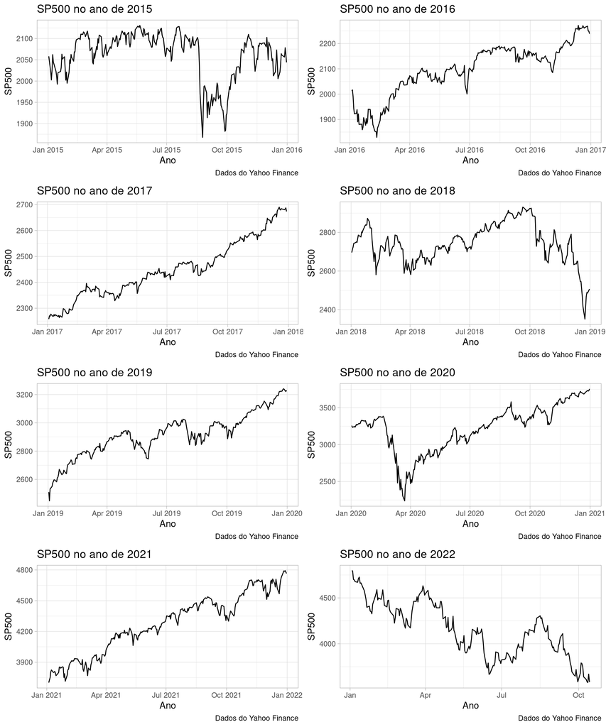

Figuras com o índice SP500 por ano

## Testando temas

Como sabemos, módulo **ggplot2** (Wickham et al. 2026) e **ggthemes** (Arnold 2026) oferecem diversos temas incluindo:

- **ggplot2::theme_bw()**
- **ggplot2::theme_grey()**
- **ggthemes::theme_excel()**
- **ggthemes::theme_economist()**

Primeiro criamos a função com tema:

```r
plot_with_theme <- function(this_theme_fct, p) {

  p <- p + this_theme_fct()

  return(p)
}
```

E agora testamos para o mesmo gráfico de preços e a função de tema **theme_economist()** :

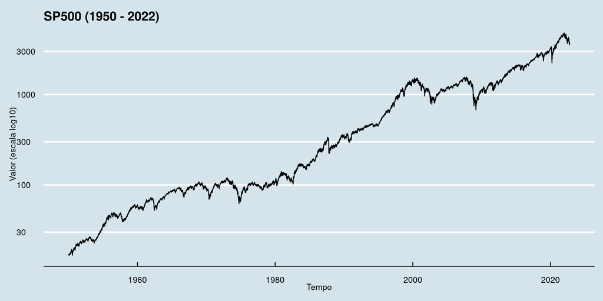

```r
p <- ggplot(df_yf,
            aes(x = ref_date,
                y = price_adjusted)) +
  geom_line() +
  labs(x = 'Tempo',
       y = "Valor (escala log10)",
       title = "SP500 (1950 - 2022)") +
  scale_y_continuous(trans='log10')


p <- plot_with_theme(ggthemes::theme_economist, p)

p
```

Agora, vamos criar uma nova função que irá exportar o resultado em arquivos no formato png.

Note que passamos a **própria função de tema** (e não o seu nome como *string*): assim evitamos `eval(parse())` e deixamos o código mais seguro e idiomático.

```r
plot_with_theme_and_export <- function(this_theme_fct,
                                       theme_label,
                                       p,
                                       path_to_save) {

  p <- plot_with_theme(this_theme_fct, p)

  fs::dir_create(path_to_save)

  p <- p +
    labs(subtitle = paste0("Tema = ", theme_label))

  file_to_save <- fs::path(
    path_to_save,
    paste0("SP500-1950-2022_",
            stringr::str_replace_all(theme_label,
                                     '::', '_' ),
            ".png")
  )

  ggsave(file_to_save, p,
         width = 10, height = 6, dpi = 300)

  return(p)

}
```

Aplicação da função:

```r
themes <- list(
  "ggplot2::theme_light"      = ggplot2::theme_light,
  "ggplot2::theme_grey"       = ggplot2::theme_grey,
  "ggthemes::theme_excel"     = ggthemes::theme_excel,
  "ggthemes::theme_economist" = ggthemes::theme_economist
)

dir_out <- fs::path_temp("testing-themes")

l_p <- purrr::imap(
  .x = themes,
  .f = function(fct, nm) plot_with_theme_and_export(
    this_theme_fct = fct,
    theme_label = nm,
    p = p,
    path_to_save = dir_out
  )
)

basename(fs::dir_ls(dir_out))
```

```
[1] "SP500-1950-2022_ggplot2_theme_grey.png"
[2] "SP500-1950-2022_ggplot2_theme_light.png"
[3] "SP500-1950-2022_ggthemes_theme_economist.png"
[4] "SP500-1950-2022_ggthemes_theme_excel.png"
```

### Resultado

[figure not shown]

Figuras com o índice SP500 por tema de gráfico

# Resumo da aula

## O que vimos

- Mapas no R com `geobr` (dados oficiais do IBGE) e `ggmap` (mapas do Google).
- Objetos no formato *SF* são desenhados com a camada `geom_sf()`.
- Figuras do `ggplot2` são objetos: podem ser guardadas em listas e manipuladas.
- `purrr::map()` e `purrr::imap()` aplicam funções a vários elementos e automatizam a produção de figuras.
- Funções com parâmetros permitem testar temas e exportar várias figuras de uma vez.

# Referências

Arnold, Jeffrey B. 2026. *Ggthemes: Extra Themes, Scales and Geoms for Ggplot2*. https://jrnold.github.io/ggthemes/.

Kahle, David, Hadley Wickham, and Scott Jackson. 2023. *Ggmap: Spatial Visualization with Ggplot2*. https://github.com/dkahle/ggmap.

Pereira, Rafael H. M., and Caio Nogueira Goncalves. 2023. *Geobr: Download Official Spatial Data Sets of Brazil*. https://github.com/ipeaGIT/geobr.

Wickham, Hadley, Winston Chang, Lionel Henry, et al. 2026. *Ggplot2: Create Elegant Data Visualisations Using the Grammar of Graphics*. https://ggplot2.tidyverse.org.